# Assignment_9 DATA607

Salma Elshahawy

10/22/2019

## Assignment overview

The New York Times web site provides a rich set of APIs, as described here: https://developer.nytimes.com/apis You’ll need to start by signing up for an API key. Your task is to choose one of the New York Times APIs, construct an interface in Python to read in the JSON data, and transform it into a pandas DataFrame.

**Important Note:**

This assignment done using R

## Methodology

I decided to pick the books API to see what is the best selling books according to New York Times ranking. After reading the API documentation, I picked the sample call endpoint and call GET method into that endpoint.

## Load the necessary libraries

```r
library(httr)
library(rjson)
library(jsonlite)
library(dplyr)
```

## Get NYT book list

First, I signed up for a NYT API, and create an app which leads to generate an API key for me. Second, I used this API inside of the GET from the httr package to retrieve the data from the site - Best selling books for this week. After that, I stored the resulted json into a variable called response.

```r
key <- 'BRnDpUYaARf4t6wEHdpdRQQQw7s48bMf'
key
```

```
## [1] "BRnDpUYaARf4t6wEHdpdRQQQw7s48bMf"
```

```r
nyt_book_list <- GET("https://api.nytimes.com/svc/books/v3/lists/overview.json?api-key=BRnDpUYaARf4t6wEHdpdRQQQw7s48bMf")
nyt_book_list
```

```
## Response [https://api.nytimes.com/svc/books/v3/lists/overview.json?api-key=BRnDpUYaARf4t6wEHdpdRQQQw7s48bMf]
##   Date: 2019-10-23 00:59
##   Status: 200
##   Content-Type: application/json; charset=UTF-8
##   Size: 130 kB
```

```r
response <- content(nyt_book_list) #view all the content structure
http_status(nyt_book_list)
```

```
## $category
## [1] "Success"
##
## $reason
## [1] "OK"
##
## $message
## [1] "Success: (200) OK"
```

## Pulling out the main attributes

```r
books <- fromJSON(nyt_book_list$url)

typeof(books) # list
```

```
## [1] "list"
```

## Convert to a dataframe

The resulted output is a list of list names(book genre) and books details nested inside the books attributes. To pull out the book details - which I need to this assignment, I constructed a for-loop to extract title, author, publisher, and book rank. Finally, store the extracted data into a new dataframe ready for further analysis.

```r
author <- vector()
publisher <- vector()
title <- vector()
rank <- vector()
list_name <- vector()
#Loop through books on the best sellers list
for ( i in 1: 18) {
  for (j in 1:5) {
      list_name <- c(response$results$lists[[i]]$list_name, list_name)
      title <- c( response$results$lists[[i]]$books[[j]]$title, title)
      author <- c( response$results$lists[[i]]$books[[j]]$author, author)
      publisher <- c( response$results$lists[[i]]$books[[j]]$publisher, publisher)
      rank <- c(  as.numeric  (response$results$lists[[i]]$books[[j]]$rank, rank   ))
  }

}

#Create a dataframe
books_df = data.frame(
  list_name = list_name,
  title = title,
  author = author,
  publisher = publisher,
  rank = rank
  )

books_df
```

| list_name | title | author | publisher | rank |
| --- | --- | --- | --- | --- |
| Young Adult Paperback Monthly | DEAR MARTIN | Nic Stone | Ember | 5 |
| Young Adult Paperback Monthly | SCYTHE | Neal Shusterman | Simon & Schuster | 5 |
| Young Adult Paperback Monthly | LONG WAY DOWN | Jason Reynolds | Atheneum/Caitlyn Dlouhy | 5 |
| Young Adult Paperback Monthly | THE ABSOLUTELY TRUE DIARY OF A PART-TIME INDIAN | Sherman Alexie | Little, Brown | 5 |
| Young Adult Paperback Monthly | SALT TO THE SEA | Ruta Sepetys | Penguin | 5 |
| Middle Grade Paperback Monthly | FRONT DESK | Kelly Yang | Arthur A. Levine | 5 |
| Middle Grade Paperback Monthly | RESTART | Gordon Korman | Scholastic | 5 |
| Middle Grade Paperback Monthly | OUT OF MY MIND | Sharon M Draper | Atheneum | 5 |
| Middle Grade Paperback Monthly | THE ONE AND ONLY IVAN | Katherine Applegate | HarperCollins | 5 |
| Middle Grade Paperback Monthly | A LONG WALK TO WATER | Linda Sue Park | Houghton Mifflin Harcourt | 5 |

[output cut: 80 more lines]

```r
is.data.frame(books_df)
```

```
## [1] TRUE
```

### Export to csv file

```r
NYT_books_df <- write.table(books_df, file = "bestNYTbooks.csv", row.names = FALSE, na="", col.names = TRUE, sep = ",")
```

### Test that the file is already created.

*Please be sure that you set working directory in Rstudio to the current working directory.*

```r
file_test("-f", "~/Desktop/MSDS_2019/Fall2019/aquisition_management_607/week_9/bestNYTbooks.csv")
```

```
## [1] TRUE
```

### open the file from local machine

```r
bestNYT_books <- read.csv(file = "bestNYTbooks.csv", header = TRUE, sep = ",")

bestNYT_books
```

| list_name | title | author | publisher | rank |
| --- | --- | --- | --- | --- |
| Young Adult Paperback Monthly | DEAR MARTIN | Nic Stone | Ember | 5 |
| Young Adult Paperback Monthly | SCYTHE | Neal Shusterman | Simon & Schuster | 5 |
| Young Adult Paperback Monthly | LONG WAY DOWN | Jason Reynolds | Atheneum/Caitlyn Dlouhy | 5 |
| Young Adult Paperback Monthly | THE ABSOLUTELY TRUE DIARY OF A PART-TIME INDIAN | Sherman Alexie | Little, Brown | 5 |
| Young Adult Paperback Monthly | SALT TO THE SEA | Ruta Sepetys | Penguin | 5 |
| Middle Grade Paperback Monthly | FRONT DESK | Kelly Yang | Arthur A. Levine | 5 |
| Middle Grade Paperback Monthly | RESTART | Gordon Korman | Scholastic | 5 |
| Middle Grade Paperback Monthly | OUT OF MY MIND | Sharon M Draper | Atheneum | 5 |
| Middle Grade Paperback Monthly | THE ONE AND ONLY IVAN | Katherine Applegate | HarperCollins | 5 |
| Middle Grade Paperback Monthly | A LONG WALK TO WATER | Linda Sue Park | Houghton Mifflin Harcourt | 5 |

[output cut: 80 more lines]

### Read from GitHub

We can open the file from the GitHub

```r
url <- 'https://raw.githubusercontent.com/salma71/MSDS_2019/master/Fall2019/aquisition_management_607/week_9/bestNYTbooks.csv'

# reading the url as a dataframe
bestNYT_books_df <- read.csv(url, header = TRUE, stringsAsFactors = FALSE)
bestNYT_books_df
```

| list_name | title | author | publisher | rank |
| --- | --- | --- | --- | --- |
| Young Adult Paperback Monthly | DEAR MARTIN | Nic Stone | Ember | 5 |
| Young Adult Paperback Monthly | SCYTHE | Neal Shusterman | Simon & Schuster | 5 |
| Young Adult Paperback Monthly | LONG WAY DOWN | Jason Reynolds | Atheneum/Caitlyn Dlouhy | 5 |
| Young Adult Paperback Monthly | THE ABSOLUTELY TRUE DIARY OF A PART-TIME INDIAN | Sherman Alexie | Little, Brown | 5 |
| Young Adult Paperback Monthly | SALT TO THE SEA | Ruta Sepetys | Penguin | 5 |
| Middle Grade Paperback Monthly | FRONT DESK | Kelly Yang | Arthur A. Levine | 5 |
| Middle Grade Paperback Monthly | RESTART | Gordon Korman | Scholastic | 5 |
| Middle Grade Paperback Monthly | OUT OF MY MIND | Sharon M Draper | Atheneum | 5 |
| Middle Grade Paperback Monthly | THE ONE AND ONLY IVAN | Katherine Applegate | HarperCollins | 5 |
| Middle Grade Paperback Monthly | A LONG WALK TO WATER | Linda Sue Park | Houghton Mifflin Harcourt | 5 |

[output cut: 80 more lines]

## Basic analysis

I had a curiousity to find out what is the most frequent publisher according to NYT best selling books.

```r
by_publisher <- books_df %>%
  group_by(publisher) %>%
  select(title, publisher) %>%
  summarize(total = n()) # how many books per publisher

by_publisher
```

| publisher | total |
| --- | --- |
| Amulet | 1 |
| Anchor | 1 |
| Arthur A. Levine | 1 |
| Atheneum | 1 |
| Atheneum/Caitlyn Dlouhy | 2 |
| Avery | 1 |
| Avid Reader/Simon & Schuster | 1 |
| Back Bay/Little, Brown | 1 |
| Beacon Press | 1 |
| Broadside | 2 |

[output cut: 44 more lines]

## Visualization

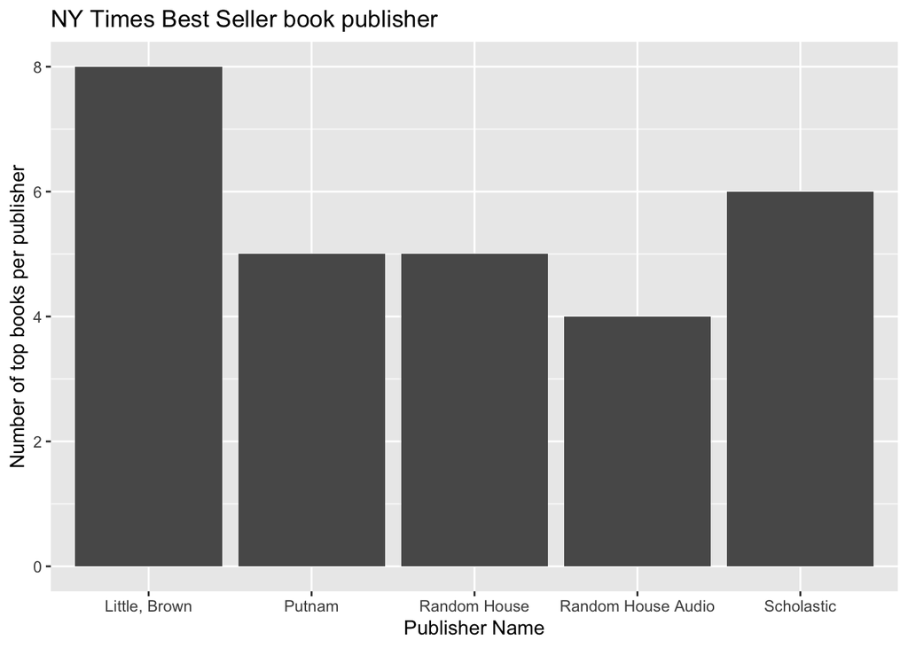

```r
library(ggplot2)
freq_publisher <- by_publisher %>%
  filter(total > 2)

ggplot( data = freq_publisher, aes  (x = publisher, y=total )) +
   geom_bar(stat="identity") +
   xlab("Publisher Name") +
   ylab("Number of top books per publisher") +
   ggtitle ("NY Times Best Seller book publisher") +
   theme(legend.position="bottom")
```

## Conclusion

It seems that the top publishers are Little Brown with 8 books per week followed by Scholastic with 6 books. However, Putnam and Random House have have the same number of books of 5 while Random House Audio has only 4 books per week.

## Links

- [GitHub Repo](https://github.com/salma71/MSDS_2019/tree/master/Fall2019/aquisition_management_607/week_9)
- [Final csv file on GitHub](https://github.com/salma71/MSDS_2019/blob/master/Fall2019/aquisition_management_607/week_9/bestNYTbooks.csv)